# introduction à la gestion des données en sciences exactes

Collège Doctoral de Bretagne

Damien Belvèze

damien.belveze@univ-rennes.fr

Université de Rennes

2023-07-11

données de recherche, de quoi parle t-on ?

[figure not shown]

## quels fichiers sont importants à mettre à disposition ?

- raw_data_spectrometer.csv
- intermediate_data.xls
- filter1.py
- first_draft_submission.pdf
- spectrometer_calibration.md
- kick_off_report.docx
- filter2.py
- notebook_experiment.ipynb
- final_data_spectrometer.xls
- project_presentation_funders.pptx
- final_data.csv
- study_draft.qmd
- january_meeting_partners.docx
- spectrometer_instructions_for_use.pdf
- gantt_calendar.xlsx

## Réponses

- raw_data_spectrometer.csv
- intermediate_data.xls
- filter1.py
- first_draft_submission.pdf
- spectrometer_calibration.md
- kick_off_report.docx
- filter2.py
- notebook_experiment.ipynb
- final_data_spectrometer.xls
- project_presentation_funders.pptx
- final_data.csv
- study_draft.qmd
- january_meeting_partners.docx
- spectrometer_instructions_for_use.pdf
- gantt_calendar.xlsx

# Pourquoi conserver ces données ?

## pérennité de l’accès aux données

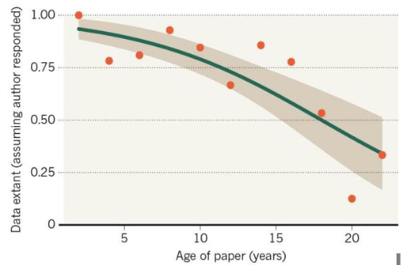

Gibney & Van Noorden (2013)

Un enjeu de Science Ouverte

[figure not shown]

## principes FAIR

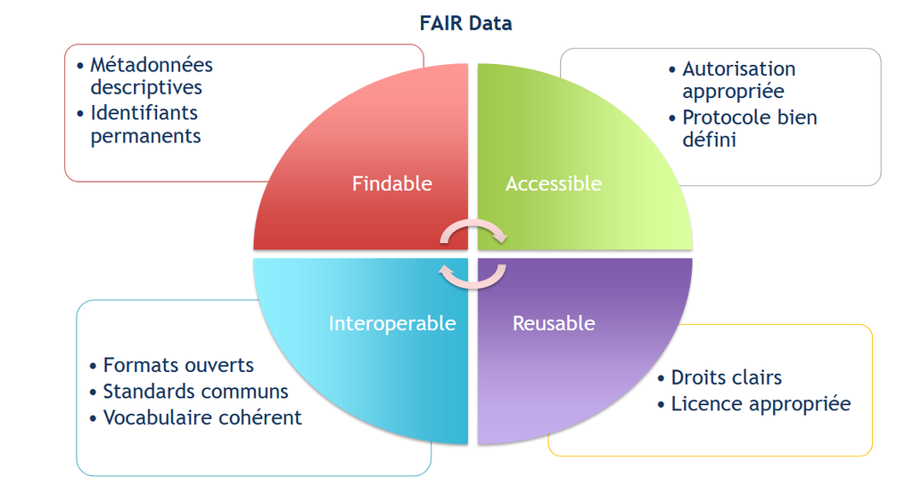

principes FAIR

## ouverture / fermeture

“aussi ouvert que possible, aussi fermé que nécessaire”

## rendre ses données trouvables

- choix d’un répertoire thématique ou institutionnel de renommée
- une description et des métadonnées riches

## données accessibles ?

## données interopérables ?

## données réutilisables ?

# sauvegarde

# archivage

# exercice

Possibilité de s’exercer sur Recherche Data Gouv

[bac à sable de RDG](https://demo.recherche.data.gouv.fr/dataverse/tp)

## Combien de silures dans la rivière Tydale tout au long de l’année

## données fictives créées avec ChatGPT

```
   Day January February March April May June July August September October
1    1       5        3     8     4   2   10   11     12         9       7
2    2       3        7     2     5   4    8    1      6        11      10
3    3       6        4     9     7  11    3    8     5#         2       1
4    4       8        1     0     3   0    9   4#      7         5       2
5    5       2       10     7    12   8    4   11      1         6       3
6    6       4        0     3     1   5    7    2     10         0      12
7    7       7        5     1     9  10    2    6      3         4      11
8    8      11       0*     6     2   3    1    7      9        12      **
9    9       1       9*     4    11  7*    5   10     2#         3      **
10  10       9       2*    10     6  1*   11   3#      8         7      **
11  11       7       6*     5     1  9*   2#   4#     11         8      **
12  12       4      11*     1     8  5*    6    9      7        10      **
13  13      12       7*     2     4 11*    3    5      6         9      **
14  14       8       5*     3     7  6*   10   1#     2#         4      **
```

[output cut: 49 more lines]

[output not shown]

## champs RDG

```
## identification du jeu de données

- titre
- Lien vers les données si pas hébergées dans RDG

## informations relatives au gestionnaire des données

- auteur
- affiliation de l'auteur
- identifiant auteur
- identifiant organisme

## informations relatives au producteur des données

- Nom
 du producteur
- Affiliation du producteur
- Nom abrégé du producteur
- logo du producteur
- URL de l'organisme du producteur

## Description du jeu de données

- Description des données
- langue
- date

## mots-clé
- terme
- URL du terme
- Nom du vocabulaire
- URL du vocabulaire
- Type de données
- autre type de données
- publication associée
- citation
- type d'identifiant
- identifiant de la publication
- URL de la publication

## informations sur la subvention

- acronyme
- titre
- identifiant de l'organisme
- lien vers le site web de l'organisme
- work package
- tâche

## déposant

- nom du déposant
- date de dépôt
```

# Références

Gibney, E., & Van Noorden, R. (2013). Scientists losing data at a rapid rate. *Nature*. https://doi.org/10.1038/nature.2013.14416